# Machine_learning

CW

15/04/2018

In this project, we aim to use data from accelerometers of 6 participants performing barbell lifts correctly and incorrectly in 5 different ways to predict how well they do it. outcome variable: classe * Class A - exactly according to the specification * Class B - throwing the elbows to the front * Class C - lifting the dumbbell only halfway * Class D - lowering the dumbbell only halfway * Class E - throwing the hips to the front

```r
setwd("/Volumes/Daisy/R/R_assignmant/machine_learning/")
library(caret)
library(randomForest)
library(rpart)
library(rpart.plot)
```

```r
trainingV <- read.csv("pml-training.csv",head=T)
testingo <- read.csv("pml-testing.csv",head=T)
set.seed(1121)
table(is.na(trainingV))
```

```
##
##   FALSE    TRUE
## 1852048 1287472
```

There many a lot of missing values, thus we first exclude variables with limited variance in prediction in training set. Same variables will be used in the testing set.

# Preprocessing

1. exclude variables with many missing values. The “No.missingVar” variable will return number of missing values for all variables.

```r
sum(is.na(trainingV))
```

```
## [1] 1287472
```

```r
missingN<-matrix()

matName<-names(trainingV)
for (i in 1:dim(trainingV)[2]) {
   t<-sum(is.na(trainingV[,i]))
   missingN <- c(missingN,t)
}

missingN <- missingN[!is.na(missingN)]
No.missingVar <- data.frame(missingN, matName)
validVar<-No.missingVar[No.missingVar$missingN ==0,]
trainingV2 <- trainingV[names(trainingV) %in% validVar$matName]
trainingV3 <- trainingV2[,-c(1,2)]
```

2. The next step is to exclude variables with zero variance (little variance)

```r
varT<-nearZeroVar(trainingV3,saveMetrics = T)
trainingV4<- trainingV3[,varT$nzv == FALSE]
```

3. Subsequently, the training dataset was seperated to a sub-training set and a validation set.

```r
valida_index <- createDataPartition(trainingV4$classe, p =.75, list = FALSE)
validation <- trainingV4[-valida_index,]
training <- trainingV4[valida_index,]
testing <- testingo[,names(testingo) %in% names(training)]

dim(validation)
```

```
## [1] 4904   57
```

```r
dim(training)
```

```
## [1] 14718    57
```

```r
dim(testing)
```

```
## [1] 20 56
```

# Creating models.

1. Here I tested three models, random forest (“rf”), rpart and gbm.

```r
modf1 <- train(classe ~., training, method ="rf")
modf2 <- train (classe ~., training, method ="rpart")
modf3 <- train (classe ~., training, method ="gbm")
```

2. This is to predict test the model using the models created in the previous step on the validation set.

```r
crossV1<- predict(modf1,newdata = validation)
crossV2<- predict(modf2,newdata = validation)
crossV3<- predict(modf3,newdata = validation)
```

3. To measure the model fit, using validation set:

```r
confusionMatrix(crossV1,validation$classe)$overall
```

```
##       Accuracy          Kappa  AccuracyLower  AccuracyUpper   AccuracyNull
##      1.0000000      1.0000000      0.9992481      1.0000000      0.2844617
## AccuracyPValue  McnemarPValue
##      0.0000000            NaN
```

```r
confusionMatrix(crossV2,validation$classe)$overall
```

```
##       Accuracy          Kappa  AccuracyLower  AccuracyUpper   AccuracyNull
##   5.010196e-01   3.744276e-01   4.869265e-01   5.151114e-01   2.844617e-01
## AccuracyPValue  McnemarPValue
##  2.213235e-223            NaN
```

```r
confusionMatrix(crossV3,validation$classe)$overall
```

```
##       Accuracy          Kappa  AccuracyLower  AccuracyUpper   AccuracyNull
##      0.9973491      0.9966468      0.9954712      0.9985878      0.2844617
## AccuracyPValue  McnemarPValue
##      0.0000000            NaN
```

Confusion Matrix shows that model 1 (random forest, method = “rf”) and model 3 (medho = “gbm”) accurately predict the validation dataset. We thus will apply the two models to the testing set.

Out of sample error rate for model 1 is 1-1.000 = 0, for model 3, out of sample error is 1 - .9973 =.0027

# predicting the testing set

```r
predict(modf1,newdata=testing)
```

```
##  [1] B A B A A E D B A A B C B A E E A B B B
## Levels: A B C D E
```

```r
predict(modf3,newdata=testing)
```

```
##  [1] B A B A A E D B A A B C B A E E A B B B
## Levels: A B C D E
```

The predictions made by the two models are identical

# Appendix

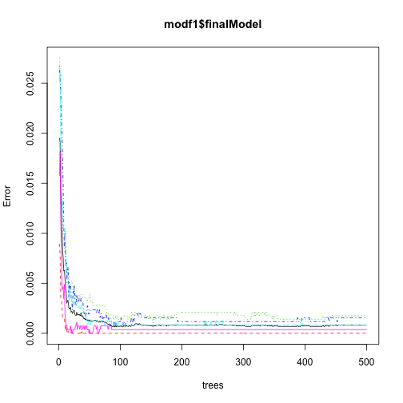

```r
plot(modf1$finalModel)
```

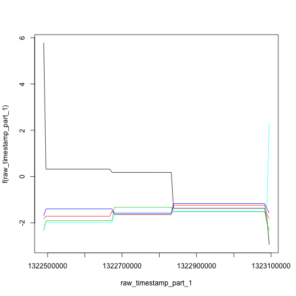

```r
plot(modf3$finalModel)
```